# IEEE TMI 2023

Bardia Yousefi

January 13,2023

Author: **Bardia Yousefi** (*Email*)

GenerateF: *January 13, 2023*

# Sandy Dataset CT

## CT Radiomics alone PR-Isomap

Here, we calculate survival analysis for PC- LD PR-iso data only for 9 Radiomics without adding clinical data.

```
## Call:
## coxph(formula = Surv(clcData$Time.to.Last.Follow.up, clcData$Survival.Status) ~
##     clcData$prisom.1 + clcData$prisom.2 + clcData$prisom.3 +
##         clcData$prisom.4 + clcData$prisom.5 + clcData$prisom.6 +
##         clcData$prisom.7 + clcData$prisom.8 + clcData$prisom.9,
##     method = "breslow")
##
##   n= 130, number of events= 27
##
##                      coef exp(coef) se(coef)      z Pr(>|z|)
## clcData$prisom.1  0.19949   1.22078  0.17574  1.135   0.2563
## clcData$prisom.2  0.70608   2.02603  0.30892  2.286   0.0223 *
## clcData$prisom.3  0.46285   1.58860  0.50507  0.916   0.3594
## clcData$prisom.4  0.42332   1.52702  0.49830  0.850   0.3956
## clcData$prisom.5 -0.73672   0.47868  0.61202 -1.204   0.2287
## clcData$prisom.6 -1.21013   0.29816  0.85923 -1.408   0.1590
## clcData$prisom.7 -0.09545   0.90896  0.77401 -0.123   0.9019
## clcData$prisom.8  0.49888   1.64688  0.78074  0.639   0.5228
## clcData$prisom.9  0.88938   2.43363  0.92624  0.960   0.3370
## ---
## Signif. codes:  0 '***' 0.001 '**' 0.01 '*' 0.05 '.' 0.1 ' ' 1
##
##                  exp(coef) exp(-coef) lower .95 upper .95
## clcData$prisom.1    1.2208     0.8191   0.86506     1.723
## clcData$prisom.2    2.0260     0.4936   1.10583     3.712
## clcData$prisom.3    1.5886     0.6295   0.59034     4.275
## clcData$prisom.4    1.5270     0.6549   0.57503     4.055
## clcData$prisom.5    0.4787     2.0891   0.14424     1.589
## clcData$prisom.6    0.2982     3.3539   0.05534     1.606
## clcData$prisom.7    0.9090     1.1002   0.19939     4.144
## clcData$prisom.8    1.6469     0.6072   0.35653     7.607
## clcData$prisom.9    2.4336     0.4109   0.39613    14.951
##
## Concordance= 0.681  (se = 0.054 )
## Likelihood ratio test= 11.47  on 9 df,   p=0.2
## Wald test            = 11.44  on 9 df,   p=0.2
## Score (logrank) test = 12.01  on 9 df,   p=0.2
```

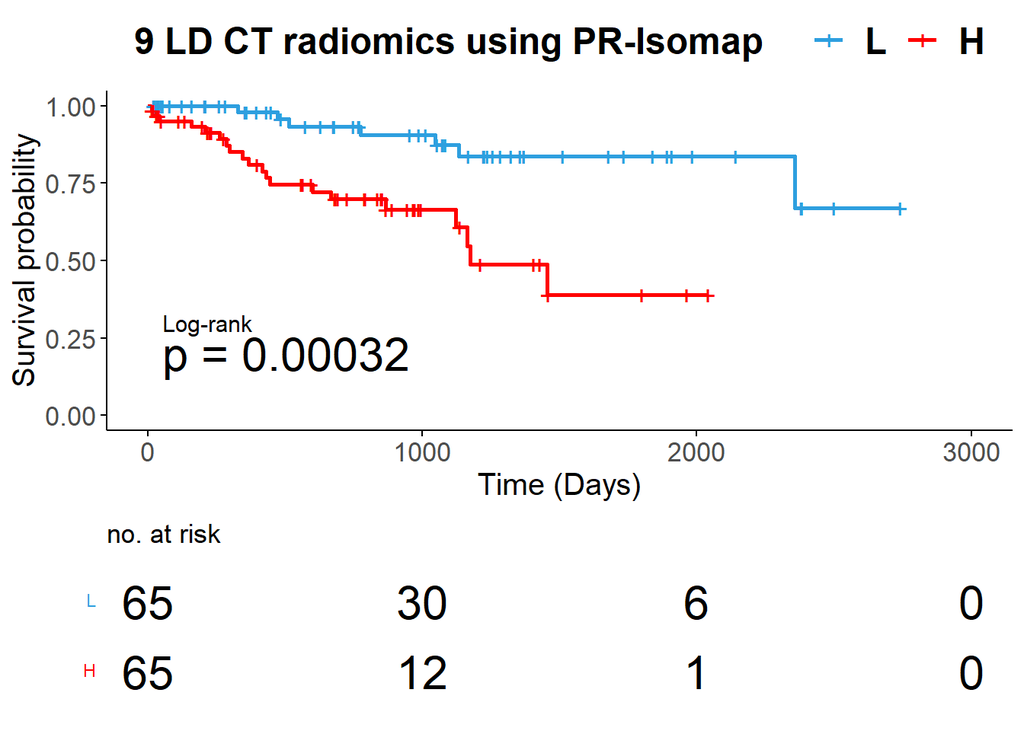

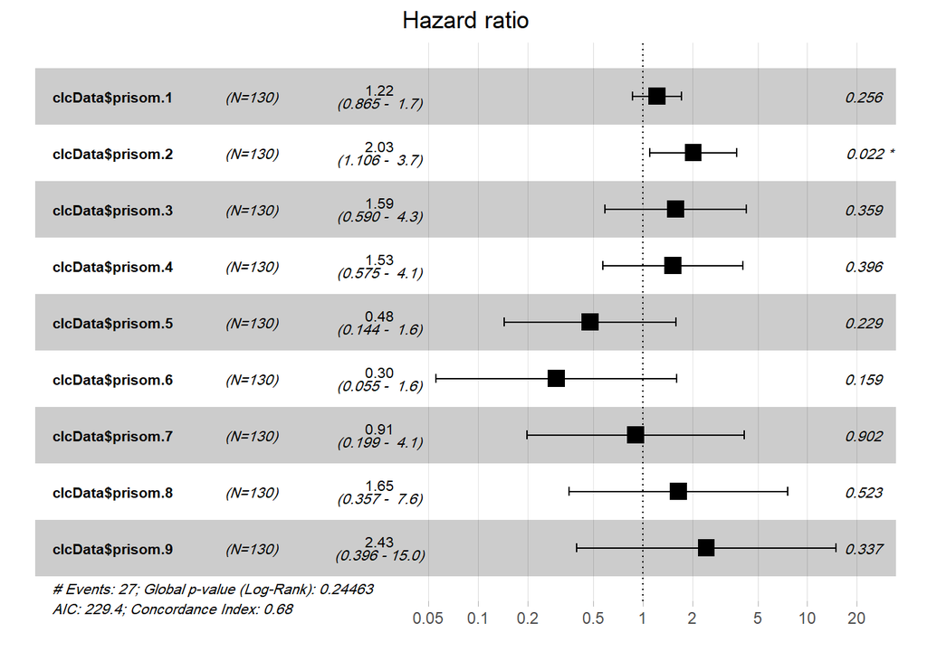

## CT Radiomics alone Original Isomap

Here, we calculate survival analysis for PC- LD Original data only for 9 Radiomics without adding clinical data.

```
## Call:
## coxph(formula = Surv(clcData$Time.to.Last.Follow.up, clcData$Survival.Status) ~
##     clcData$isom.1 + clcData$isom.2 + clcData$isom.3 + clcData$isom.4 +
##         clcData$isom.5 + clcData$isom.6 + clcData$isom.7 + clcData$isom.8 +
##         clcData$isom.9, method = "breslow")
##
##   n= 130, number of events= 27
##
##                    coef exp(coef) se(coef)      z Pr(>|z|)
## clcData$isom.1 -0.02888   0.97154  0.01934 -1.493   0.1353
## clcData$isom.2  0.06702   1.06932  0.02833  2.366   0.0180 *
## clcData$isom.3  0.12548   1.13370  0.05511  2.277   0.0228 *
## clcData$isom.4 -0.09280   0.91138  0.05236 -1.772   0.0764 .
## clcData$isom.5 -0.06167   0.94020  0.04675 -1.319   0.1871
## clcData$isom.6 -0.01249   0.98759  0.06739 -0.185   0.8530
## clcData$isom.7 -0.17676   0.83798  0.07096 -2.491   0.0127 *
## clcData$isom.8 -0.09679   0.90775  0.07696 -1.258   0.2085
## clcData$isom.9  0.04972   1.05098  0.05908  0.842   0.4000
## ---
## Signif. codes:  0 '***' 0.001 '**' 0.01 '*' 0.05 '.' 0.1 ' ' 1
##
##                exp(coef) exp(-coef) lower .95 upper .95
## clcData$isom.1    0.9715     1.0293    0.9354     1.009
## clcData$isom.2    1.0693     0.9352    1.0116     1.130
## clcData$isom.3    1.1337     0.8821    1.0176     1.263
## clcData$isom.4    0.9114     1.0972    0.8225     1.010
## clcData$isom.5    0.9402     1.0636    0.8579     1.030
## clcData$isom.6    0.9876     1.0126    0.8654     1.127
## clcData$isom.7    0.8380     1.1933    0.7292     0.963
## clcData$isom.8    0.9077     1.1016    0.7806     1.056
## clcData$isom.9    1.0510     0.9515    0.9361     1.180
##
## Concordance= 0.664  (se = 0.065 )
## Likelihood ratio test= 16.6  on 9 df,   p=0.06
## Wald test            = 19.71  on 9 df,   p=0.02
## Score (logrank) test = 14.17  on 9 df,   p=0.1
```

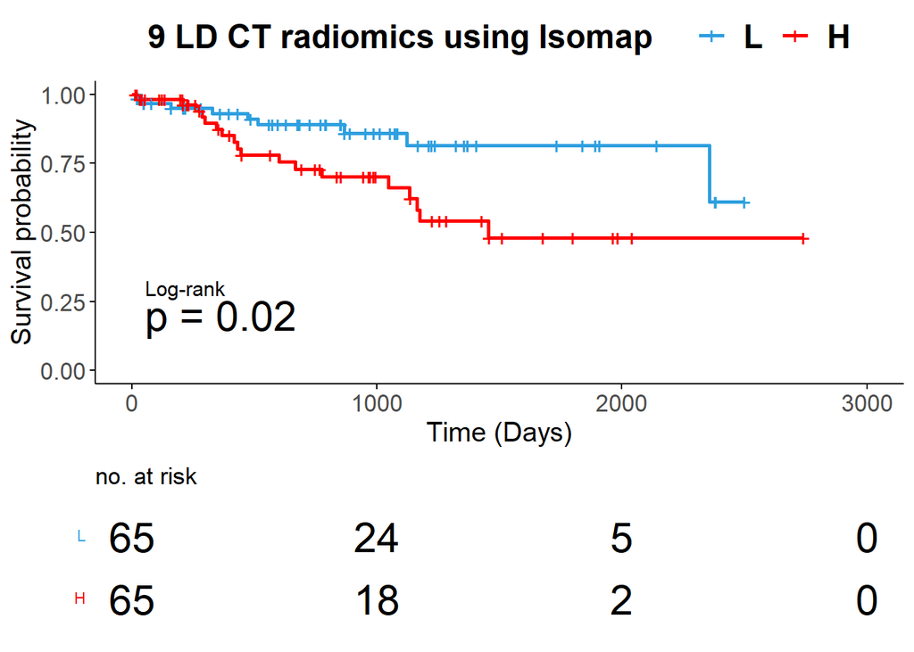

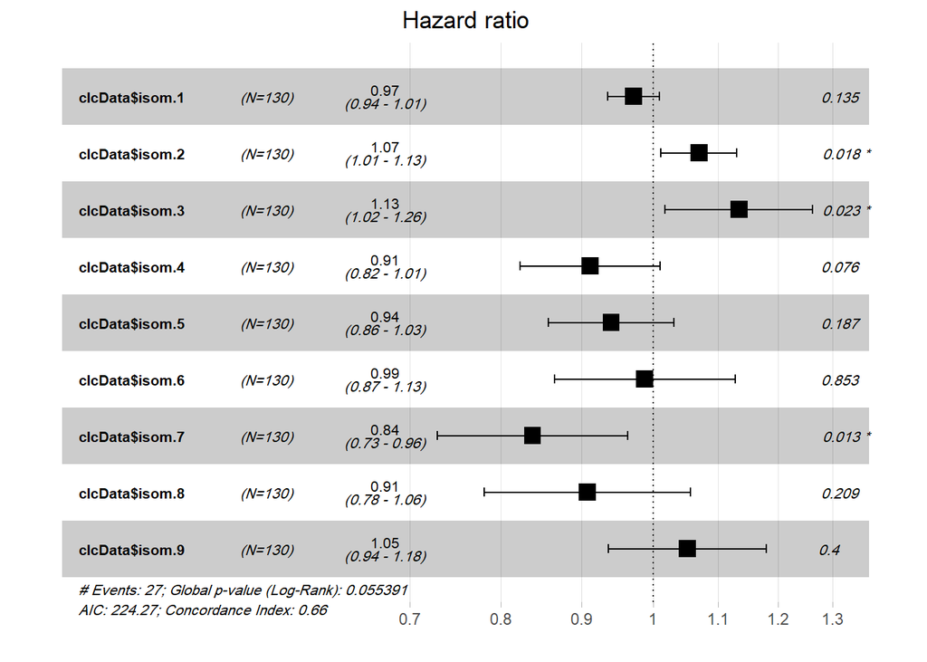

## CT Radiomics alone PCA

Here, we calculate survival analysis for PC- LD PCA data only for 9 Radiomics without adding clinical data.

```
## Call:
## coxph(formula = Surv(clcData$Time.to.Last.Follow.up, clcData$Survival.Status) ~
##     clcData$pca.1 + clcData$pca.2 + clcData$pca.3 + clcData$pca.4 +
##         clcData$pca.5 + clcData$pca.6 + clcData$pca.7 + clcData$pca.8 +
##         clcData$pca.9, method = "breslow")
##
##   n= 130, number of events= 27
##
##                    coef exp(coef)  se(coef)      z Pr(>|z|)
## clcData$pca.1 -0.012841  0.987241  0.052922 -0.243    0.808
## clcData$pca.2  0.058538  1.060285  0.041500  1.411    0.158
## clcData$pca.3 -0.070195  0.932212  0.121121 -0.580    0.562
## clcData$pca.4 -0.021985  0.978255  0.068863 -0.319    0.750
## clcData$pca.5 -0.036466  0.964191  0.059905 -0.609    0.543
## clcData$pca.6 -0.033962  0.966608  0.116732 -0.291    0.771
## clcData$pca.7  0.002768  1.002772  0.166548  0.017    0.987
## clcData$pca.8  0.053277  1.054722  0.068453  0.778    0.436
## clcData$pca.9  0.097780  1.102720  0.105260  0.929    0.353
##
##               exp(coef) exp(-coef) lower .95 upper .95
## clcData$pca.1    0.9872     1.0129    0.8900     1.095
## clcData$pca.2    1.0603     0.9431    0.9775     1.150
## clcData$pca.3    0.9322     1.0727    0.7352     1.182
## clcData$pca.4    0.9783     1.0222    0.8547     1.120
## clcData$pca.5    0.9642     1.0371    0.8574     1.084
## clcData$pca.6    0.9666     1.0345    0.7689     1.215
## clcData$pca.7    1.0028     0.9972    0.7235     1.390
## clcData$pca.8    1.0547     0.9481    0.9223     1.206
## clcData$pca.9    1.1027     0.9068    0.8972     1.355
##
## Concordance= 0.636  (se = 0.073 )
## Likelihood ratio test= 7.92  on 9 df,   p=0.5
## Wald test            = 8.88  on 9 df,   p=0.4
## Score (logrank) test = 10.31  on 9 df,   p=0.3
```

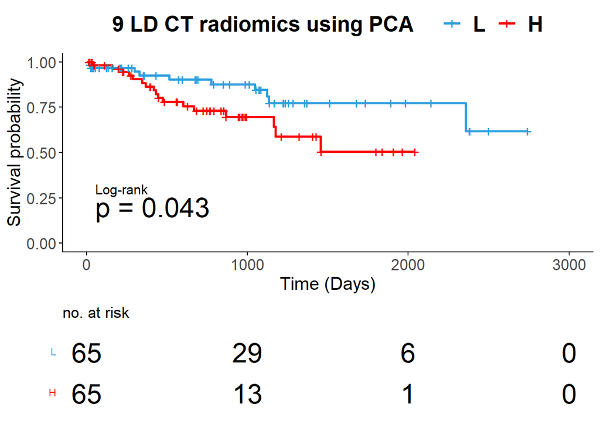

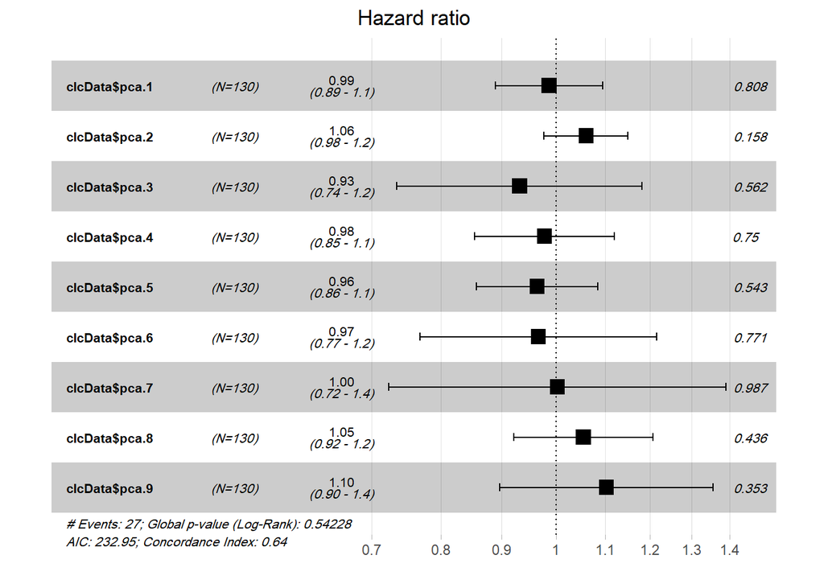

## CT Radiomics alone tSNE

Here, we calculate survival analysis for PC- LD tSNE data only for 9 Radiomics without adding clinical data.

```
## Call:
## coxph(formula = Surv(clcData$Time.to.Last.Follow.up, clcData$Survival.Status) ~
##     clcData$tsne.1 + clcData$tsne.2 + clcData$tsne.3 + clcData$tsne.4 +
##         clcData$tsne.5 + clcData$tsne.6 + clcData$tsne.7 + clcData$tsne.8 +
##         clcData$tsne.9, method = "breslow")
##
##   n= 130, number of events= 27
##
##                    coef exp(coef) se(coef)      z Pr(>|z|)
## clcData$tsne.1 -0.01761   0.98254  0.03844 -0.458    0.647
## clcData$tsne.2  0.04291   1.04385  0.03244  1.323    0.186
## clcData$tsne.3 -0.02404   0.97624  0.02505 -0.960    0.337
## clcData$tsne.4  0.01713   1.01728  0.02554  0.671    0.502
## clcData$tsne.5  0.01806   1.01822  0.03044  0.593    0.553
## clcData$tsne.6 -0.01519   0.98493  0.03836 -0.396    0.692
## clcData$tsne.7 -0.03318   0.96736  0.03092 -1.073    0.283
## clcData$tsne.8  0.05756   1.05925  0.03507  1.641    0.101
## clcData$tsne.9  0.07165   1.07428  0.03398  2.108    0.035 *
## ---
## Signif. codes:  0 '***' 0.001 '**' 0.01 '*' 0.05 '.' 0.1 ' ' 1
##
##                exp(coef) exp(-coef) lower .95 upper .95
## clcData$tsne.1    0.9825     1.0178    0.9112     1.059
## clcData$tsne.2    1.0438     0.9580    0.9795     1.112
## clcData$tsne.3    0.9762     1.0243    0.9295     1.025
## clcData$tsne.4    1.0173     0.9830    0.9676     1.070
## clcData$tsne.5    1.0182     0.9821    0.9593     1.081
## clcData$tsne.6    0.9849     1.0153    0.9136     1.062
## clcData$tsne.7    0.9674     1.0337    0.9105     1.028
## clcData$tsne.8    1.0592     0.9441    0.9889     1.135
## clcData$tsne.9    1.0743     0.9309    1.0051     1.148
##
## Concordance= 0.642  (se = 0.056 )
## Likelihood ratio test= 9.21  on 9 df,   p=0.4
## Wald test            = 10.09  on 9 df,   p=0.3
## Score (logrank) test = 9.8  on 9 df,   p=0.4
```

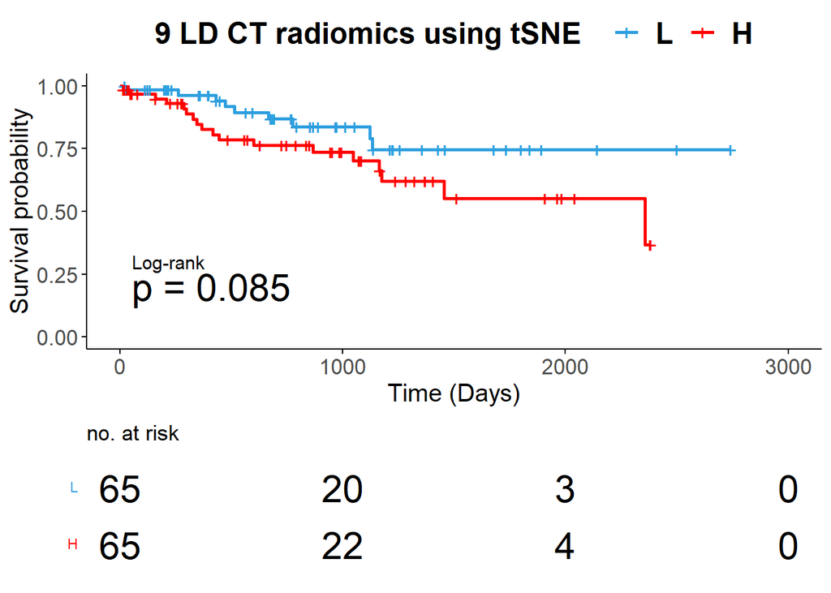

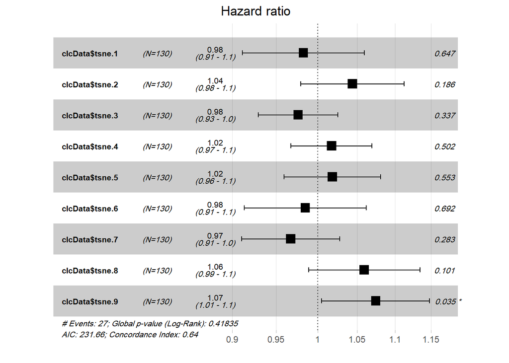

# Sandy PET

## PET Radiomics alone PR-Isomap

Here, we calculate survival analysis for PC- LD PR-iso data only for 9 Radiomics without adding clinical data.

```
## Call:
## coxph(formula = Surv(clcData$Time.to.Last.Follow.up, clcData$Survival.Status) ~
##     clcData$prisom.1 + clcData$prisom.2 + clcData$prisom.3 +
##         clcData$prisom.4 + clcData$prisom.5 + clcData$prisom.6 +
##         clcData$prisom.7 + clcData$prisom.8 + clcData$prisom.9,
##     method = "breslow")
##
##   n= 130, number of events= 27
##
##                      coef exp(coef) se(coef)      z Pr(>|z|)
## clcData$prisom.1  0.20937   1.23290  0.21042  0.995    0.320
## clcData$prisom.2 -0.22794   0.79617  0.27425 -0.831    0.406
## clcData$prisom.3  0.37013   1.44792  0.34460  1.074    0.283
## clcData$prisom.4 -0.71068   0.49131  0.43733 -1.625    0.104
## clcData$prisom.5 -0.04269   0.95821  0.46085 -0.093    0.926
## clcData$prisom.6 -0.22778   0.79630  0.60515 -0.376    0.707
## clcData$prisom.7  0.22783   1.25587  0.55815  0.408    0.683
## clcData$prisom.8 -0.56703   0.56721  0.66015 -0.859    0.390
## clcData$prisom.9  0.98069   2.66631  0.68840  1.425    0.154
##
##                  exp(coef) exp(-coef) lower .95 upper .95
## clcData$prisom.1    1.2329     0.8111    0.8162     1.862
## clcData$prisom.2    0.7962     1.2560    0.4651     1.363
## clcData$prisom.3    1.4479     0.6906    0.7369     2.845
## clcData$prisom.4    0.4913     2.0354    0.2085     1.158
## clcData$prisom.5    0.9582     1.0436    0.3883     2.364
## clcData$prisom.6    0.7963     1.2558    0.2432     2.607
## clcData$prisom.7    1.2559     0.7963    0.4206     3.750
## clcData$prisom.8    0.5672     1.7630    0.1555     2.069
## clcData$prisom.9    2.6663     0.3751    0.6917    10.277
##
## Concordance= 0.672  (se = 0.051 )
## Likelihood ratio test= 8.95  on 9 df,   p=0.4
## Wald test            = 10.09  on 9 df,   p=0.3
## Score (logrank) test = 9.81  on 9 df,   p=0.4
```

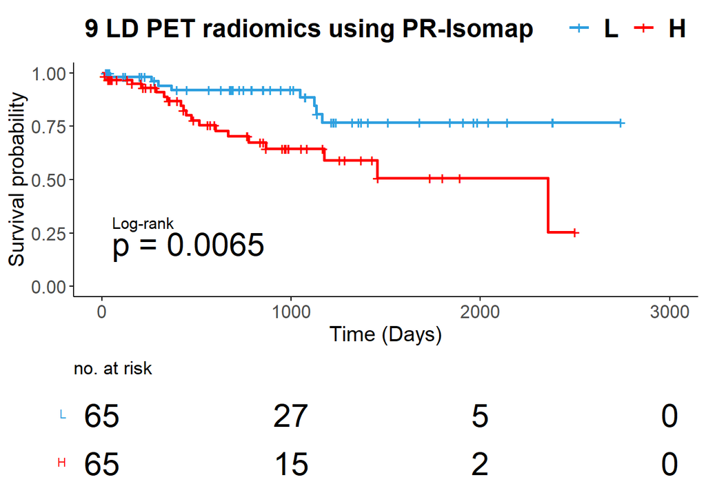

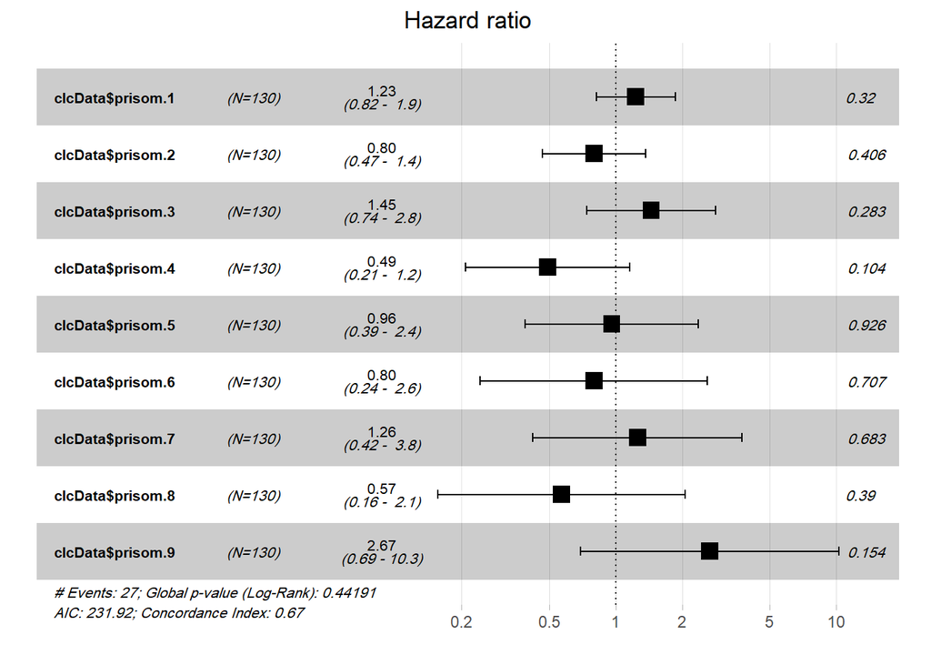

## PET Radiomics alone Original Isomap

Here, we calculate survival analysis for PC- LD Original data only for 9 Radiomics without adding clinical data.

```
## Call:
## coxph(formula = Surv(clcData$Time.to.Last.Follow.up, clcData$Survival.Status) ~
##     clcData$isom.1 + clcData$isom.2 + clcData$isom.3 + clcData$isom.4 +
##         clcData$isom.5 + clcData$isom.6 + clcData$isom.7 + clcData$isom.8 +
##         clcData$isom.9, method = "breslow")
##
##   n= 130, number of events= 27
##
##                      coef  exp(coef)   se(coef)      z Pr(>|z|)
## clcData$isom.1  0.0004578  1.0004579  0.0082867  0.055   0.9559
## clcData$isom.2  0.0191589  1.0193436  0.0169814  1.128   0.2592
## clcData$isom.3 -0.0177925  0.9823648  0.0201330 -0.884   0.3768
## clcData$isom.4 -0.0812753  0.9219398  0.0338462 -2.401   0.0163 *
## clcData$isom.5 -0.0354587  0.9651626  0.0403237 -0.879   0.3792
## clcData$isom.6 -0.0068734  0.9931502  0.0345413 -0.199   0.8423
## clcData$isom.7 -0.0184700  0.9816995  0.0342695 -0.539   0.5899
## clcData$isom.8  0.0137527  1.0138477  0.0468608  0.293   0.7692
## clcData$isom.9 -0.0566371  0.9449370  0.0465861 -1.216   0.2241
## ---
## Signif. codes:  0 '***' 0.001 '**' 0.01 '*' 0.05 '.' 0.1 ' ' 1
##
##                exp(coef) exp(-coef) lower .95 upper .95
## clcData$isom.1    1.0005     0.9995    0.9843    1.0168
## clcData$isom.2    1.0193     0.9810    0.9860    1.0538
## clcData$isom.3    0.9824     1.0180    0.9444    1.0219
## clcData$isom.4    0.9219     1.0847    0.8628    0.9852
## clcData$isom.5    0.9652     1.0361    0.8918    1.0445
## clcData$isom.6    0.9932     1.0069    0.9281    1.0627
## clcData$isom.7    0.9817     1.0186    0.9179    1.0499
## clcData$isom.8    1.0138     0.9863    0.9249    1.1114
## clcData$isom.9    0.9449     1.0583    0.8625    1.0353
##
## Concordance= 0.673  (se = 0.053 )
## Likelihood ratio test= 12.35  on 9 df,   p=0.2
## Wald test            = 13.18  on 9 df,   p=0.2
## Score (logrank) test = 10.16  on 9 df,   p=0.3
```

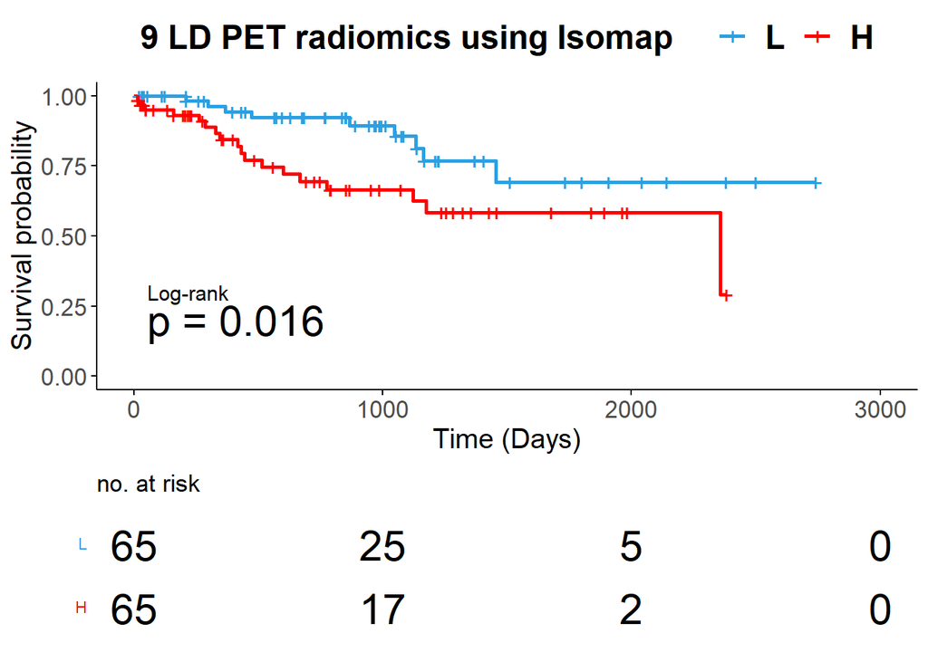

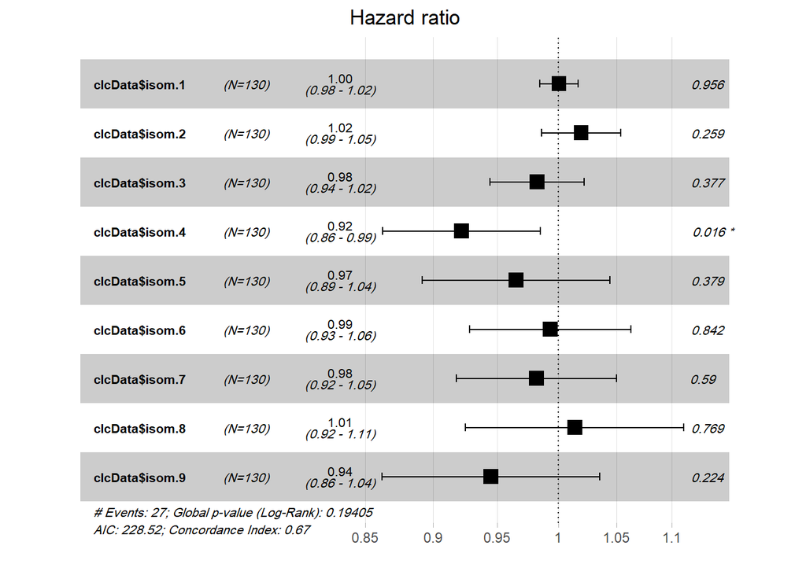

## PET Radiomics alone PCA

Here, we calculate survival analysis for PC- LD PCA data only for 9 Radiomics without adding clinical data.

```
## Call:
## coxph(formula = Surv(clcData$Time.to.Last.Follow.up, clcData$Survival.Status) ~
##     clcData$pca.1 + clcData$pca.2 + clcData$pca.3 + clcData$pca.4 +
##         clcData$pca.5 + clcData$pca.6 + clcData$pca.7 + clcData$pca.8 +
##         clcData$pca.9, method = "breslow")
##
##   n= 130, number of events= 27
##
##                   coef exp(coef) se(coef)      z Pr(>|z|)
## clcData$pca.1  0.02724   1.02762  0.01475  1.847   0.0648 .
## clcData$pca.2  0.03461   1.03522  0.04438  0.780   0.4355
## clcData$pca.3  0.01128   1.01134  0.07135  0.158   0.8744
## clcData$pca.4 -0.08675   0.91691  0.07198 -1.205   0.2281
## clcData$pca.5 -0.05206   0.94927  0.07902 -0.659   0.5100
## clcData$pca.6  0.02961   1.03006  0.04510  0.657   0.5114
## clcData$pca.7  0.14950   1.16126  0.08162  1.832   0.0670 .
## clcData$pca.8 -0.01565   0.98447  0.06259 -0.250   0.8025
## clcData$pca.9 -0.12143   0.88566  0.10875 -1.117   0.2642
## ---
## Signif. codes:  0 '***' 0.001 '**' 0.01 '*' 0.05 '.' 0.1 ' ' 1
##
##               exp(coef) exp(-coef) lower .95 upper .95
## clcData$pca.1    1.0276     0.9731    0.9983     1.058
## clcData$pca.2    1.0352     0.9660    0.9490     1.129
## clcData$pca.3    1.0113     0.9888    0.8793     1.163
## clcData$pca.4    0.9169     1.0906    0.7963     1.056
## clcData$pca.5    0.9493     1.0534    0.8131     1.108
## clcData$pca.6    1.0301     0.9708    0.9429     1.125
## clcData$pca.7    1.1613     0.8611    0.9896     1.363
## clcData$pca.8    0.9845     1.0158    0.8708     1.113
## clcData$pca.9    0.8857     1.1291    0.7156     1.096
##
## Concordance= 0.688  (se = 0.053 )
## Likelihood ratio test= 15.14  on 9 df,   p=0.09
## Wald test            = 15.67  on 9 df,   p=0.07
## Score (logrank) test = 18  on 9 df,   p=0.04
```

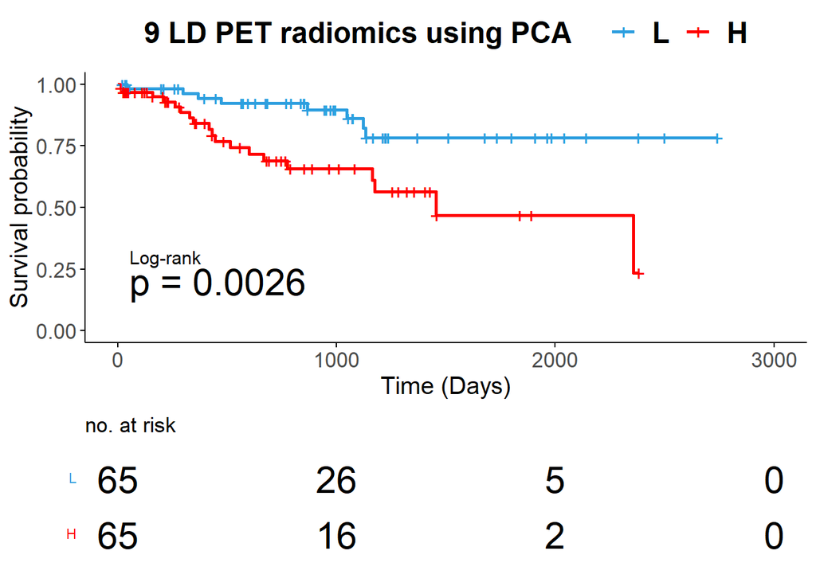

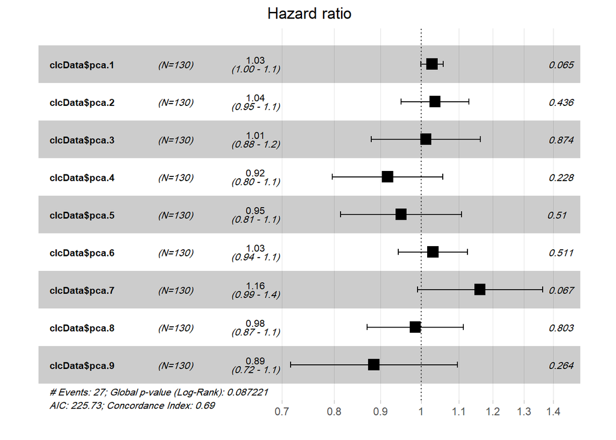

## PET Radiomics alone tSNE

Here, we calculate survival analysis for PC- LD tSNE data only for 9 Radiomics without adding clinical data.

```
## Call:
## coxph(formula = Surv(clcData$Time.to.Last.Follow.up, clcData$Survival.Status) ~
##     clcData$prisom.1 + clcData$prisom.2 + clcData$prisom.3 +
##         clcData$prisom.4 + clcData$prisom.5 + clcData$prisom.6 +
##         clcData$prisom.7 + clcData$prisom.8 + clcData$prisom.9,
##     method = "breslow")
##
##   n= 130, number of events= 27
##
##                       coef exp(coef)  se(coef)      z Pr(>|z|)
## clcData$prisom.1  0.024557  1.024861  0.042073  0.584   0.5594
## clcData$prisom.2 -0.034189  0.966389  0.031811 -1.075   0.2825
## clcData$prisom.3  0.006135  1.006154  0.025839  0.237   0.8123
## clcData$prisom.4 -0.077602  0.925333  0.034321 -2.261   0.0238 *
## clcData$prisom.5 -0.025031  0.975279  0.025411 -0.985   0.3246
## clcData$prisom.6  0.022963  1.023229  0.027967  0.821   0.4116
## clcData$prisom.7 -0.021058  0.979162  0.028155 -0.748   0.4545
## clcData$prisom.8  0.003570  1.003576  0.018099  0.197   0.8436
## clcData$prisom.9 -0.021565  0.978666  0.017299 -1.247   0.2125
## ---
## Signif. codes:  0 '***' 0.001 '**' 0.01 '*' 0.05 '.' 0.1 ' ' 1
##
##                  exp(coef) exp(-coef) lower .95 upper .95
## clcData$prisom.1    1.0249     0.9757    0.9437    1.1130
## clcData$prisom.2    0.9664     1.0348    0.9080    1.0286
## clcData$prisom.3    1.0062     0.9939    0.9565    1.0584
## clcData$prisom.4    0.9253     1.0807    0.8651    0.9897
## clcData$prisom.5    0.9753     1.0253    0.9279    1.0251
## clcData$prisom.6    1.0232     0.9773    0.9687    1.0809
## clcData$prisom.7    0.9792     1.0213    0.9266    1.0347
## clcData$prisom.8    1.0036     0.9964    0.9686    1.0398
## clcData$prisom.9    0.9787     1.0218    0.9460    1.0124
##
## Concordance= 0.602  (se = 0.064 )
## Likelihood ratio test= 10.5  on 9 df,   p=0.3
## Wald test            = 11.83  on 9 df,   p=0.2
## Score (logrank) test = 10.57  on 9 df,   p=0.3
```

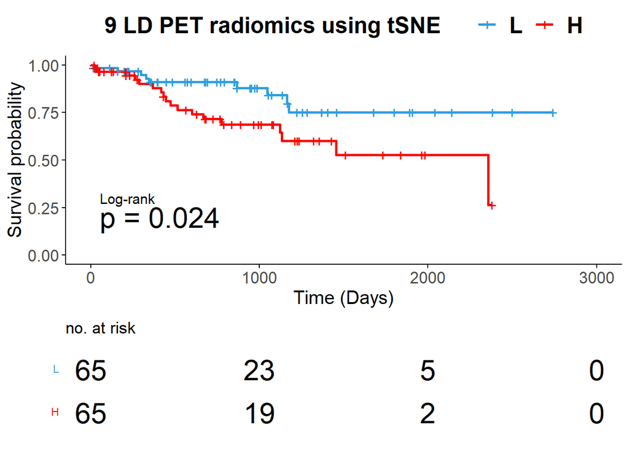

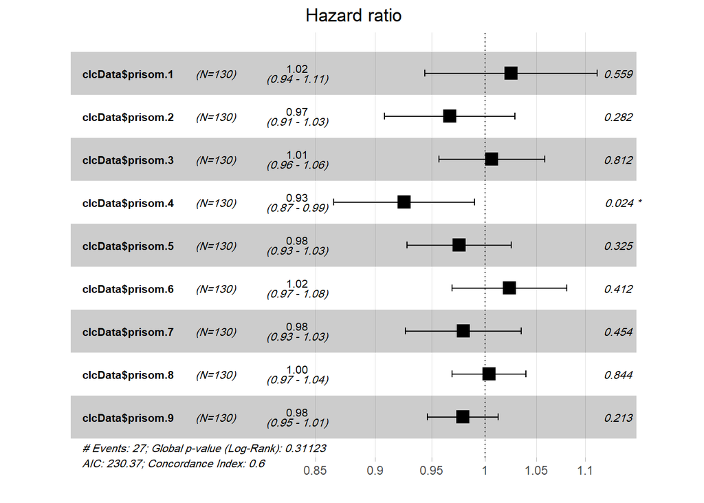

## PET Radiomics alone UMAP

Here, we calculate survival analysis for PC- LD UMAP data only for 9 Radiomics without adding clinical data.

```
## Call:
## coxph(formula = Surv(clcData$Time.to.Last.Follow.up, clcData$Survival.Status) ~
##     clcData$prisom.1 + clcData$prisom.2 + clcData$prisom.3 +
##         clcData$prisom.4 + clcData$prisom.5 + clcData$prisom.6 +
##         clcData$prisom.7 + clcData$prisom.8 + clcData$prisom.9,
##     method = "breslow")
##
##   n= 130, number of events= 27
##
##                      coef exp(coef) se(coef)      z Pr(>|z|)
## clcData$prisom.1  2.92170  18.57289  1.70778  1.711   0.0871 .
## clcData$prisom.2  1.09459   2.98796  2.24493  0.488   0.6258
## clcData$prisom.3  3.71573  41.08872  3.24931  1.144   0.2528
## clcData$prisom.4  0.27387   1.31504  1.05207  0.260   0.7946
## clcData$prisom.5  1.28735   3.62318  2.40709  0.535   0.5928
## clcData$prisom.6 -3.26415   0.03823  2.93668 -1.112   0.2663
## clcData$prisom.7  2.88627  17.92640  2.05974  1.401   0.1611
## clcData$prisom.8 -0.32818   0.72024  1.65090 -0.199   0.8424
## clcData$prisom.9  1.21042   3.35490  0.69223  1.749   0.0804 .
## ---
## Signif. codes:  0 '***' 0.001 '**' 0.01 '*' 0.05 '.' 0.1 ' ' 1
##
##                  exp(coef) exp(-coef) lower .95 upper .95
## clcData$prisom.1  18.57289    0.05384  0.653454    527.89
## clcData$prisom.2   2.98796    0.33468  0.036685    243.37
## clcData$prisom.3  41.08872    0.02434  0.070454  23962.87
## clcData$prisom.4   1.31504    0.76043  0.167270     10.34
## clcData$prisom.5   3.62318    0.27600  0.032372    405.52
## clcData$prisom.6   0.03823   26.15780  0.000121     12.08
## clcData$prisom.7  17.92640    0.05578  0.316400   1015.66
## clcData$prisom.8   0.72024    1.38843  0.028328     18.31
## clcData$prisom.9   3.35490    0.29807  0.863878     13.03
##
## Concordance= 0.701  (se = 0.059 )
## Likelihood ratio test= 11.55  on 9 df,   p=0.2
## Wald test            = 12.86  on 9 df,   p=0.2
## Score (logrank) test = 14.18  on 9 df,   p=0.1
```

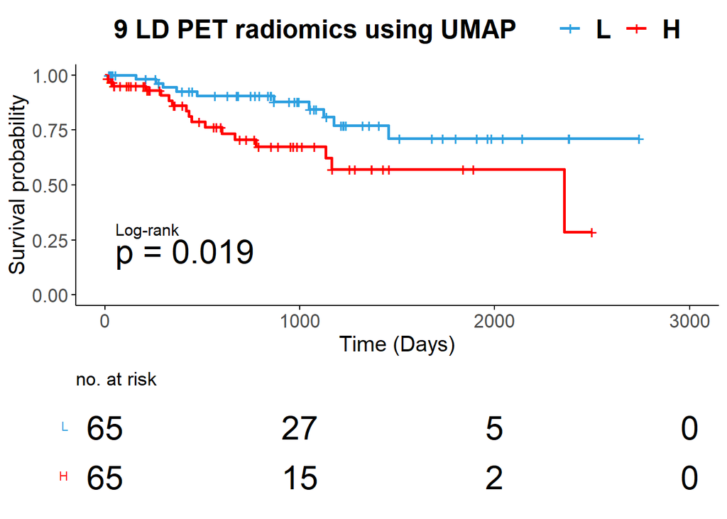

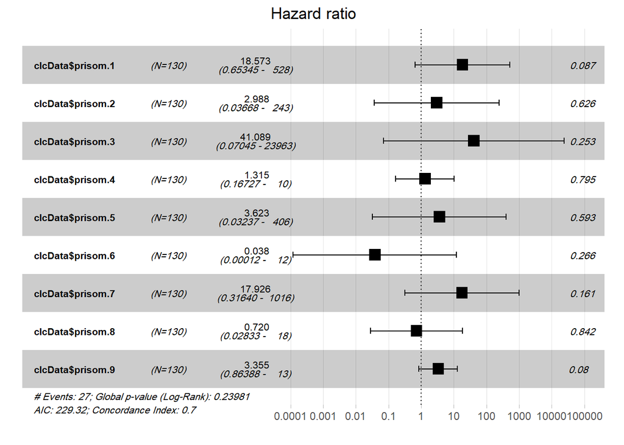

## PET Radiomics alone tSNE

Here, we calculate survival analysis for PC- LD tSNE data only for 9 Radiomics without adding clinical data.

```
## Call:
## coxph(formula = Surv(clcData$Time.to.Last.Follow.up, clcData$Survival.Status) ~
##     clcData$prisom.1 + clcData$prisom.2 + clcData$prisom.3 +
##         clcData$prisom.4 + clcData$prisom.5 + clcData$prisom.6 +
##         clcData$prisom.7 + clcData$prisom.8 + clcData$prisom.9,
##     method = "breslow")
##
##   n= 130, number of events= 27
##
##                       coef exp(coef)  se(coef)      z Pr(>|z|)
## clcData$prisom.1  0.024557  1.024861  0.042073  0.584   0.5594
## clcData$prisom.2 -0.034189  0.966389  0.031811 -1.075   0.2825
## clcData$prisom.3  0.006135  1.006154  0.025839  0.237   0.8123
## clcData$prisom.4 -0.077602  0.925333  0.034321 -2.261   0.0238 *
## clcData$prisom.5 -0.025031  0.975279  0.025411 -0.985   0.3246
## clcData$prisom.6  0.022963  1.023229  0.027967  0.821   0.4116
## clcData$prisom.7 -0.021058  0.979162  0.028155 -0.748   0.4545
## clcData$prisom.8  0.003570  1.003576  0.018099  0.197   0.8436
## clcData$prisom.9 -0.021565  0.978666  0.017299 -1.247   0.2125
## ---
## Signif. codes:  0 '***' 0.001 '**' 0.01 '*' 0.05 '.' 0.1 ' ' 1
##
##                  exp(coef) exp(-coef) lower .95 upper .95
## clcData$prisom.1    1.0249     0.9757    0.9437    1.1130
## clcData$prisom.2    0.9664     1.0348    0.9080    1.0286
## clcData$prisom.3    1.0062     0.9939    0.9565    1.0584
## clcData$prisom.4    0.9253     1.0807    0.8651    0.9897
## clcData$prisom.5    0.9753     1.0253    0.9279    1.0251
## clcData$prisom.6    1.0232     0.9773    0.9687    1.0809
## clcData$prisom.7    0.9792     1.0213    0.9266    1.0347
## clcData$prisom.8    1.0036     0.9964    0.9686    1.0398
## clcData$prisom.9    0.9787     1.0218    0.9460    1.0124
##
## Concordance= 0.602  (se = 0.064 )
## Likelihood ratio test= 10.5  on 9 df,   p=0.3
## Wald test            = 11.83  on 9 df,   p=0.2
## Score (logrank) test = 10.57  on 9 df,   p=0.3
```

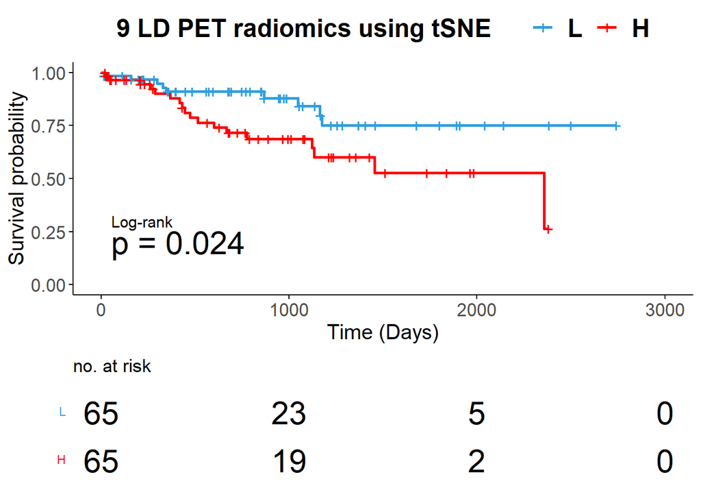

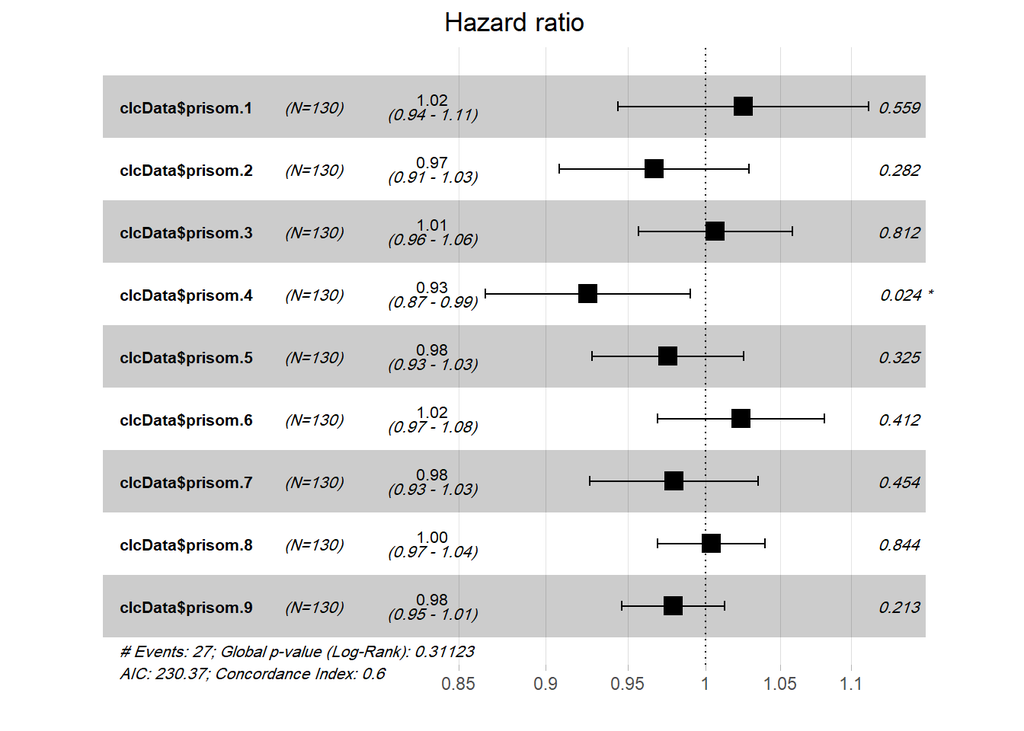

## Sandy all the covarients

We calculate radiomics with clinical covariats.

```
## Call:
## coxph(formula = Surv(clcData$Time.to.Last.Follow.up, clcData$Survival.Status) ~
##     clcData$prisom.1 + clcData$prisom.2 + clcData$prisom.3 +
##         clcData$prisom.4 + clcData$prisom.5 + clcData$prisom.6 +
##         clcData$prisom.7 + clcData$prisom.8 + clcData$prisom.9 +
##         clcData$prisom.1 + clcData$prisom.2 + clcData$prisom.3 +
##         clcData$prisom.4 + clcData$prisom.5 + clcData$prisom.6 +
##         clcData$prisom.7 + clcData$prisom.8 + clcData$prisom.9 +
##         clcData$Gender + clcData$Smoking.status, method = "breslow")
##
##   n= 130, number of events= 27
##
##                            coef exp(coef) se(coef)      z Pr(>|z|)
## clcData$prisom.1        0.16927   1.18444  0.17790  0.951   0.3414
## clcData$prisom.2        0.69488   2.00347  0.30608  2.270   0.0232 *
## clcData$prisom.3        0.29995   1.34979  0.52625  0.570   0.5687
## clcData$prisom.4        0.47097   1.60155  0.50996  0.924   0.3557
## clcData$prisom.5       -0.46731   0.62669  0.63944 -0.731   0.4649
## clcData$prisom.6       -0.92609   0.39610  0.86565 -1.070   0.2847
## clcData$prisom.7       -0.28011   0.75570  0.76953 -0.364   0.7159
## clcData$prisom.8        0.45544   1.57687  0.78259  0.582   0.5606
## clcData$prisom.9        0.76044   2.13921  0.91611  0.830   0.4065
## clcData$Gender         -0.94888   0.38717  0.68506 -1.385   0.1660
## clcData$Smoking.status  0.04141   1.04228  0.38720  0.107   0.9148
## ---
## Signif. codes:  0 '***' 0.001 '**' 0.01 '*' 0.05 '.' 0.1 ' ' 1
##
##                        exp(coef) exp(-coef) lower .95 upper .95
## clcData$prisom.1          1.1844     0.8443    0.8358     1.679
## clcData$prisom.2          2.0035     0.4991    1.0996     3.650
## clcData$prisom.3          1.3498     0.7409    0.4812     3.786
## clcData$prisom.4          1.6015     0.6244    0.5895     4.351
## clcData$prisom.5          0.6267     1.5957    0.1790     2.195
## clcData$prisom.6          0.3961     2.5246    0.0726     2.161
## clcData$prisom.7          0.7557     1.3233    0.1672     3.415
## clcData$prisom.8          1.5769     0.6342    0.3401     7.310
## clcData$prisom.9          2.1392     0.4675    0.3552    12.884
## clcData$Gender            0.3872     2.5828    0.1011     1.483
## clcData$Smoking.status    1.0423     0.9594    0.4880     2.226
##
## Concordance= 0.718  (se = 0.051 )
## Likelihood ratio test= 13.77  on 11 df,   p=0.2
## Wald test            = 12.39  on 11 df,   p=0.3
## Score (logrank) test = 13.45  on 11 df,   p=0.3
```

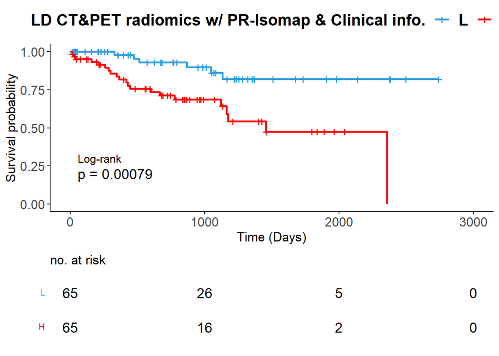

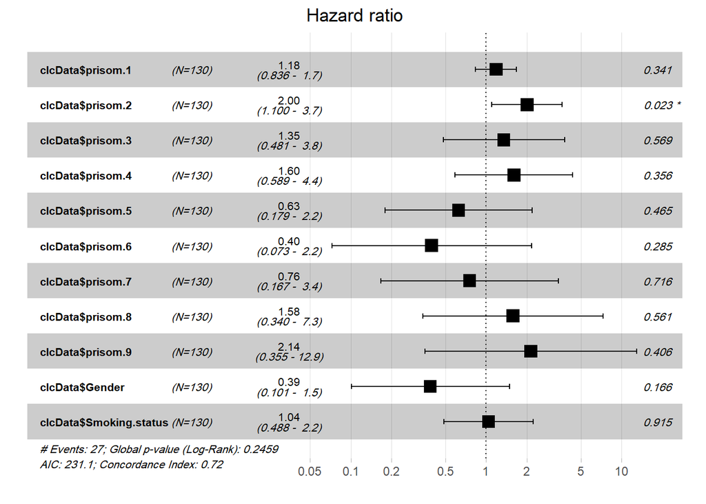

# Lung 01

## CT Radiomics - PRisomap

Here, we calculate survival analysis for LD LUNG01 data only for 12 Radiomics without adding clinical data.

```
## Call:
## coxph(formula = Surv(clcData$time, clcData$event) ~ clcData$prisom.1 +
##     clcData$prisom.2 + clcData$prisom.3 + clcData$prisom.4 +
##     clcData$prisom.5 + clcData$prisom.6 + clcData$prisom.7 +
##     clcData$prisom.8 + clcData$prisom.9 + clcData$prisom.10 +
##     clcData$prisom.11 + clcData$prisom.12, method = "breslow")
##
##   n= 422, number of events= 373
##
##                       coef exp(coef) se(coef)      z Pr(>|z|)
## clcData$prisom.1  -0.03504   0.96557  0.06334 -0.553  0.58015
## clcData$prisom.2  -0.25561   0.77444  0.08101 -3.155  0.00160 **
## clcData$prisom.3   0.11133   1.11776  0.09531  1.168  0.24280
## clcData$prisom.4   0.30953   1.36278  0.11216  2.760  0.00579 **
## clcData$prisom.5  -0.01129   0.98877  0.13177 -0.086  0.93171
## clcData$prisom.6  -0.23853   0.78778  0.14040 -1.699  0.08934 .
## clcData$prisom.7  -0.07607   0.92676  0.15054 -0.505  0.61336
## clcData$prisom.8   0.15448   1.16705  0.15598  0.990  0.32199
## clcData$prisom.9  -0.08764   0.91609  0.16839 -0.520  0.60274
## clcData$prisom.10 -0.34666   0.70705  0.18011 -1.925  0.05427 .
## clcData$prisom.11  0.10324   1.10876  0.17947  0.575  0.56512
## clcData$prisom.12 -0.07837   0.92462  0.18073 -0.434  0.66457
## ---
## Signif. codes:  0 '***' 0.001 '**' 0.01 '*' 0.05 '.' 0.1 ' ' 1
##
##                   exp(coef) exp(-coef) lower .95 upper .95
## clcData$prisom.1     0.9656     1.0357    0.8528    1.0932
## clcData$prisom.2     0.7744     1.2912    0.6608    0.9077
## clcData$prisom.3     1.1178     0.8946    0.9273    1.3474
## clcData$prisom.4     1.3628     0.7338    1.0938    1.6978
## clcData$prisom.5     0.9888     1.0114    0.7637    1.2801
## clcData$prisom.6     0.7878     1.2694    0.5983    1.0373
## clcData$prisom.7     0.9268     1.0790    0.6900    1.2448
## clcData$prisom.8     1.1671     0.8569    0.8596    1.5844
## clcData$prisom.9     0.9161     1.0916    0.6586    1.2743
## clcData$prisom.10    0.7070     1.4143    0.4967    1.0064
## clcData$prisom.11    1.1088     0.9019    0.7800    1.5762
## clcData$prisom.12    0.9246     1.0815    0.6488    1.3177
##
## Concordance= 0.586  (se = 0.016 )
## Likelihood ratio test= 24.8  on 12 df,   p=0.02
## Wald test            = 27  on 12 df,   p=0.008
## Score (logrank) test = 26.8  on 12 df,   p=0.008
```

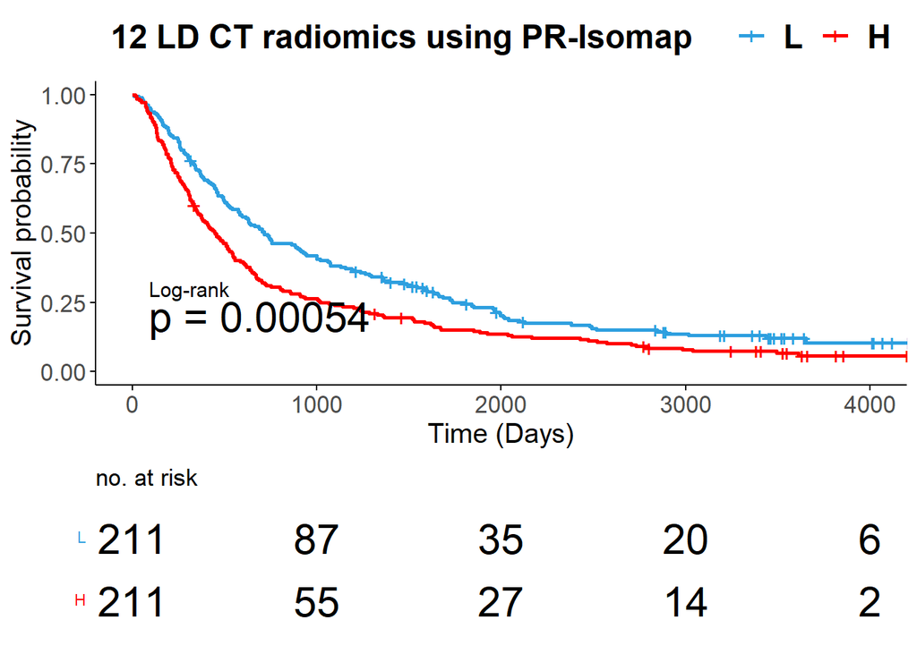

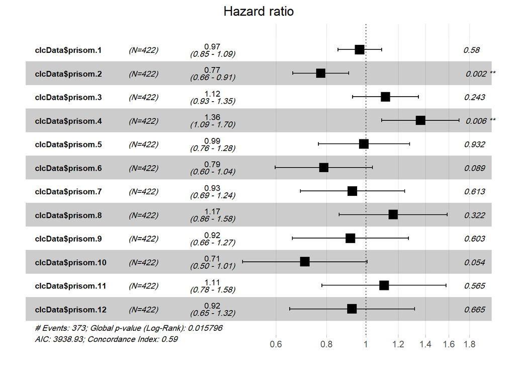

## CT Radiomics - Standard Isomap

Here, we calculate survival analysis for LD LUNG01 data only for 12 Radiomics without adding clinical data.

```
## Call:
## coxph(formula = Surv(clcData$time, clcData$event) ~ clcData$isom.1 +
##     clcData$isom.2 + clcData$isom.3 + clcData$isom.4 + clcData$isom.5 +
##     clcData$isom.6 + clcData$isom.7 + clcData$isom.8 + clcData$isom.9 +
##     clcData$isom.10 + clcData$isom.11 + clcData$isom.12, method = "breslow")
##
##   n= 422, number of events= 373
##
##                       coef  exp(coef)   se(coef)      z Pr(>|z|)
## clcData$isom.1   3.954e-13  1.000e+00  1.733e-13  2.282   0.0225 *
## clcData$isom.2  -2.082e-12  1.000e+00  8.497e-13 -2.450   0.0143 *
## clcData$isom.3   9.887e-13  1.000e+00  1.731e-12  0.571   0.5678
## clcData$isom.4   4.216e-12  1.000e+00  1.218e-11  0.346   0.7292
## clcData$isom.5  -1.339e-12  1.000e+00  1.640e-11 -0.082   0.9349
## clcData$isom.6   3.026e-11  1.000e+00  2.565e-11  1.180   0.2381
## clcData$isom.7   1.932e-11  1.000e+00  2.937e-11  0.658   0.5107
## clcData$isom.8  -4.278e-11  1.000e+00  4.411e-11 -0.970   0.3321
## clcData$isom.9  -2.308e-11  1.000e+00  3.552e-11 -0.650   0.5159
## clcData$isom.10  3.217e-11  1.000e+00  5.512e-11  0.584   0.5595
## clcData$isom.11 -1.160e-11  1.000e+00  5.330e-11 -0.218   0.8278
## clcData$isom.12  5.285e-12  1.000e+00  5.928e-11  0.089   0.9290
## ---
## Signif. codes:  0 '***' 0.001 '**' 0.01 '*' 0.05 '.' 0.1 ' ' 1
##
##                 exp(coef) exp(-coef) lower .95 upper .95
## clcData$isom.1          1          1         1         1
## clcData$isom.2          1          1         1         1
## clcData$isom.3          1          1         1         1
## clcData$isom.4          1          1         1         1
## clcData$isom.5          1          1         1         1
## clcData$isom.6          1          1         1         1
## clcData$isom.7          1          1         1         1
## clcData$isom.8          1          1         1         1
## clcData$isom.9          1          1         1         1
## clcData$isom.10         1          1         1         1
## clcData$isom.11         1          1         1         1
## clcData$isom.12         1          1         1         1
##
## Concordance= 0.548  (se = 0.016 )
## Likelihood ratio test= 10.78  on 12 df,   p=0.5
## Wald test            = 13.56  on 12 df,   p=0.3
## Score (logrank) test = 14.15  on 12 df,   p=0.3
```

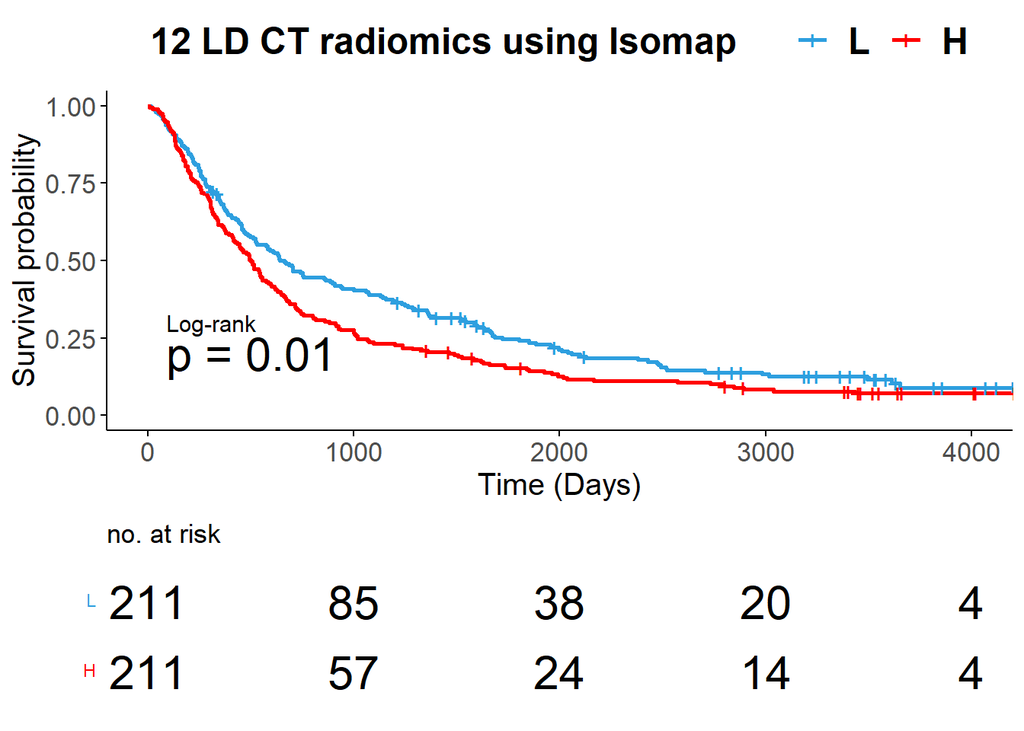

[figure not shown]

## CT Radiomics - PCA

Here, we calculate survival analysis for LD LUNG01 data only for 12 Radiomics without adding clinical data.

```
## Call:
## coxph(formula = Surv(clcData$time, clcData$event) ~ clcData$isom.1 +
##     clcData$isom.2 + clcData$isom.3 + clcData$isom.4 + clcData$isom.5 +
##     clcData$isom.6 + clcData$isom.7 + clcData$isom.8 + clcData$isom.9 +
##     clcData$isom.10 + clcData$isom.11 + clcData$isom.12, method = "breslow")
##
##   n= 422, number of events= 373
##
##                      coef exp(coef)  se(coef)      z Pr(>|z|)
## clcData$isom.1   0.002510  1.002513  0.004659  0.539 0.590104
## clcData$isom.2  -0.021682  0.978551  0.006384 -3.396 0.000683 ***
## clcData$isom.3  -0.004147  0.995862  0.008210 -0.505 0.613473
## clcData$isom.4   0.012707  1.012788  0.008982  1.415 0.157121
## clcData$isom.5  -0.013385  0.986704  0.010223 -1.309 0.190417
## clcData$isom.6  -0.003002  0.997003  0.013678 -0.219 0.826293
## clcData$isom.7  -0.006486  0.993535  0.015294 -0.424 0.671512
## clcData$isom.8  -0.030452  0.970007  0.013963 -2.181 0.029191 *
## clcData$isom.9   0.014836  1.014947  0.017845  0.831 0.405757
## clcData$isom.10 -0.015718  0.984405  0.020169 -0.779 0.435805
## clcData$isom.11 -0.024747  0.975557  0.021513 -1.150 0.250018
## clcData$isom.12  0.018526  1.018699  0.024029  0.771 0.440712
## ---
## Signif. codes:  0 '***' 0.001 '**' 0.01 '*' 0.05 '.' 0.1 ' ' 1
##
##                 exp(coef) exp(-coef) lower .95 upper .95
## clcData$isom.1     1.0025     0.9975    0.9934    1.0117
## clcData$isom.2     0.9786     1.0219    0.9664    0.9909
## clcData$isom.3     0.9959     1.0042    0.9800    1.0120
## clcData$isom.4     1.0128     0.9874    0.9951    1.0308
## clcData$isom.5     0.9867     1.0135    0.9671    1.0067
## clcData$isom.6     0.9970     1.0030    0.9706    1.0241
## clcData$isom.7     0.9935     1.0065    0.9642    1.0238
## clcData$isom.8     0.9700     1.0309    0.9438    0.9969
## clcData$isom.9     1.0149     0.9853    0.9801    1.0511
## clcData$isom.10    0.9844     1.0158    0.9463    1.0241
## clcData$isom.11    0.9756     1.0251    0.9353    1.0176
## clcData$isom.12    1.0187     0.9816    0.9718    1.0678
##
## Concordance= 0.576  (se = 0.016 )
## Likelihood ratio test= 19.34  on 12 df,   p=0.08
## Wald test            = 20.51  on 12 df,   p=0.06
## Score (logrank) test = 20.53  on 12 df,   p=0.06
```

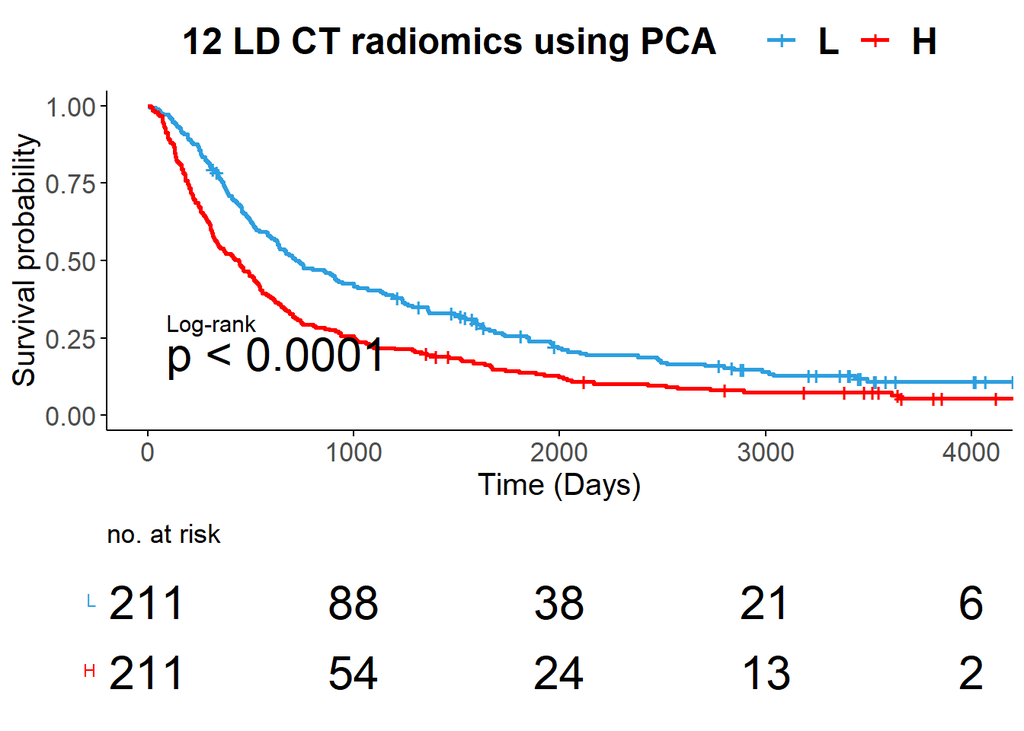

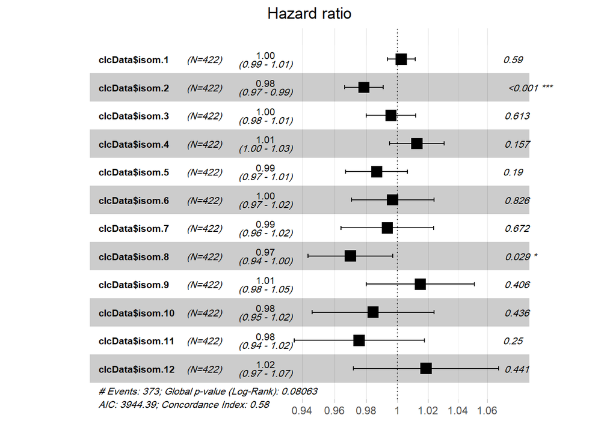

## CT Radiomics - tSNE

Here, we calculate survival analysis for LD LUNG01 data only for 12 Radiomics without adding clinical data.

```
## Call:
## coxph(formula = Surv(clcData$time, clcData$event) ~ clcData$tsne.1 +
##     clcData$tsne.2 + clcData$tsne.3 + clcData$tsne.4 + clcData$tsne.5 +
##     clcData$tsne.6 + clcData$tsne.7 + clcData$tsne.8 + clcData$tsne.9 +
##     clcData$tsne.10 + clcData$tsne.11 + clcData$tsne.12, method = "breslow")
##
##   n= 422, number of events= 373
##
##                      coef exp(coef)  se(coef)      z Pr(>|z|)
## clcData$tsne.1   0.018428  1.018599  0.011457  1.609   0.1077
## clcData$tsne.2  -0.004315  0.995695  0.007042 -0.613   0.5401
## clcData$tsne.3  -0.007349  0.992678  0.008993 -0.817   0.4138
## clcData$tsne.4   0.022883  1.023146  0.010947  2.090   0.0366 *
## clcData$tsne.5   0.008246  1.008280  0.006103  1.351   0.1767
## clcData$tsne.6   0.006381  1.006401  0.012739  0.501   0.6165
## clcData$tsne.7   0.016913  1.017057  0.008862  1.909   0.0563 .
## clcData$tsne.8  -0.007895  0.992136  0.008207 -0.962   0.3361
## clcData$tsne.9   0.001883  1.001885  0.015890  0.119   0.9057
## clcData$tsne.10  0.003021  1.003025  0.009953  0.303   0.7615
## clcData$tsne.11  0.003563  1.003570  0.008934  0.399   0.6900
## clcData$tsne.12 -0.023765  0.976515  0.009731 -2.442   0.0146 *
## ---
## Signif. codes:  0 '***' 0.001 '**' 0.01 '*' 0.05 '.' 0.1 ' ' 1
##
##                 exp(coef) exp(-coef) lower .95 upper .95
## clcData$tsne.1     1.0186     0.9817    0.9960    1.0417
## clcData$tsne.2     0.9957     1.0043    0.9820    1.0095
## clcData$tsne.3     0.9927     1.0074    0.9753    1.0103
## clcData$tsne.4     1.0231     0.9774    1.0014    1.0453
## clcData$tsne.5     1.0083     0.9918    0.9963    1.0204
## clcData$tsne.6     1.0064     0.9936    0.9816    1.0318
## clcData$tsne.7     1.0171     0.9832    0.9995    1.0349
## clcData$tsne.8     0.9921     1.0079    0.9763    1.0082
## clcData$tsne.9     1.0019     0.9981    0.9712    1.0336
## clcData$tsne.10    1.0030     0.9970    0.9836    1.0228
## clcData$tsne.11    1.0036     0.9964    0.9861    1.0213
## clcData$tsne.12    0.9765     1.0240    0.9581    0.9953
##
## Concordance= 0.552  (se = 0.016 )
## Likelihood ratio test= 14.46  on 12 df,   p=0.3
## Wald test            = 14.05  on 12 df,   p=0.3
## Score (logrank) test = 13.73  on 12 df,   p=0.3
```

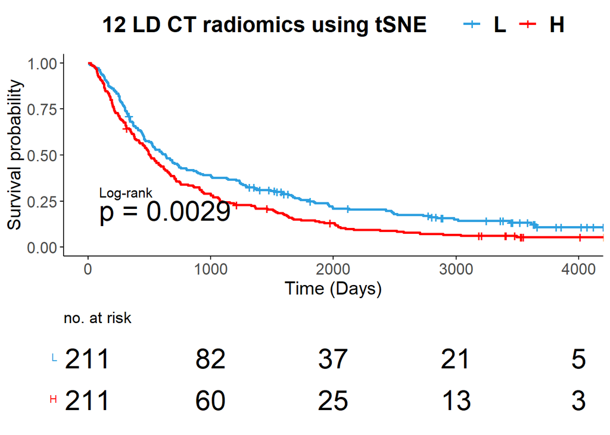

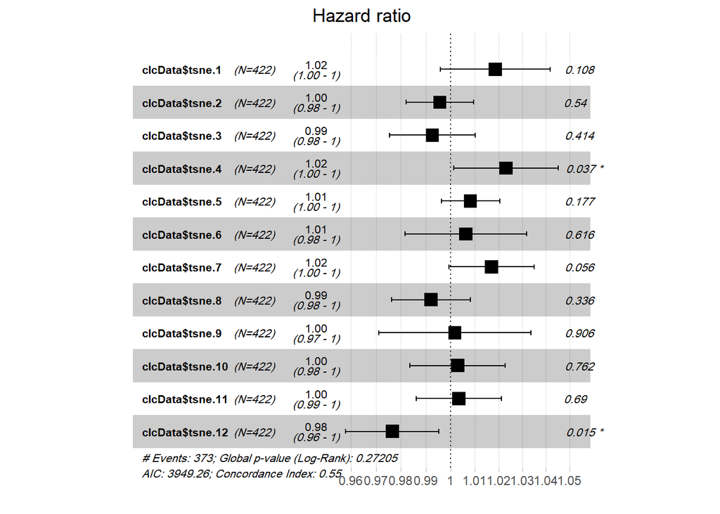

## CT Radiomics - PRisomap All covarients

Here, we calculate survival analysis for LD LUNG01 data only for 12 Radiomics with clinical data.

```
## Call:
## coxph(formula = Surv(clcData$time, clcData$event) ~ clcData$prisom.1 +
##     clcData$prisom.2 + clcData$prisom.3 + clcData$prisom.4 +
##     clcData$prisom.5 + clcData$prisom.6 + clcData$prisom.7 +
##     clcData$prisom.8 + clcData$prisom.9 + clcData$prisom.10 +
##     clcData$prisom.11 + clcData$prisom.12 + clcData$Overall.Stage +
##     clcData$Histology + clcData$gender, method = "breslow")
##
##   n= 422, number of events= 373
##
##                            coef exp(coef)  se(coef)      z Pr(>|z|)
## clcData$prisom.1      -0.073133  0.929477  0.064969 -1.126 0.260314
## clcData$prisom.2      -0.277610  0.757592  0.083983 -3.306 0.000948 ***
## clcData$prisom.3       0.124351  1.132413  0.095207  1.306 0.191516
## clcData$prisom.4       0.318253  1.374725  0.111958  2.843 0.004474 **
## clcData$prisom.5      -0.033055  0.967485  0.131833 -0.251 0.802018
## clcData$prisom.6      -0.212707  0.808393  0.140603 -1.513 0.130326
## clcData$prisom.7      -0.008844  0.991195  0.153195 -0.058 0.953962
## clcData$prisom.8       0.184990  1.203207  0.155215  1.192 0.233327
## clcData$prisom.9      -0.036255  0.964394  0.170675 -0.212 0.831778
## clcData$prisom.10     -0.255750  0.774335  0.184773 -1.384 0.166317
## clcData$prisom.11      0.082577  1.086082  0.181981  0.454 0.649997
## clcData$prisom.12     -0.067309  0.934906  0.180491 -0.373 0.709206
## clcData$Overall.Stage -0.079478  0.923599  0.047536 -1.672 0.094539 .
## clcData$Histology     -0.048460  0.952696  0.044254 -1.095 0.273494
## clcData$gender         0.198695  1.219810  0.120924  1.643 0.100352
## ---
## Signif. codes:  0 '***' 0.001 '**' 0.01 '*' 0.05 '.' 0.1 ' ' 1
##
##                       exp(coef) exp(-coef) lower .95 upper .95
## clcData$prisom.1         0.9295     1.0759    0.8183    1.0557
## clcData$prisom.2         0.7576     1.3200    0.6426    0.8931
## clcData$prisom.3         1.1324     0.8831    0.9396    1.3647
## clcData$prisom.4         1.3747     0.7274    1.1039    1.7120
## clcData$prisom.5         0.9675     1.0336    0.7472    1.2527
## clcData$prisom.6         0.8084     1.2370    0.6137    1.0649
## clcData$prisom.7         0.9912     1.0089    0.7341    1.3383
## clcData$prisom.8         1.2032     0.8311    0.8876    1.6310
## clcData$prisom.9         0.9644     1.0369    0.6902    1.3475
## clcData$prisom.10        0.7743     1.2914    0.5391    1.1123
## clcData$prisom.11        1.0861     0.9207    0.7603    1.5515
## clcData$prisom.12        0.9349     1.0696    0.6563    1.3317
## clcData$Overall.Stage    0.9236     1.0827    0.8414    1.0138
## clcData$Histology        0.9527     1.0497    0.8735    1.0390
## clcData$gender           1.2198     0.8198    0.9624    1.5460
##
## Concordance= 0.589  (se = 0.016 )
## Likelihood ratio test= 31.99  on 15 df,   p=0.006
## Wald test            = 35.1  on 15 df,   p=0.002
## Score (logrank) test = 34.78  on 15 df,   p=0.003
```

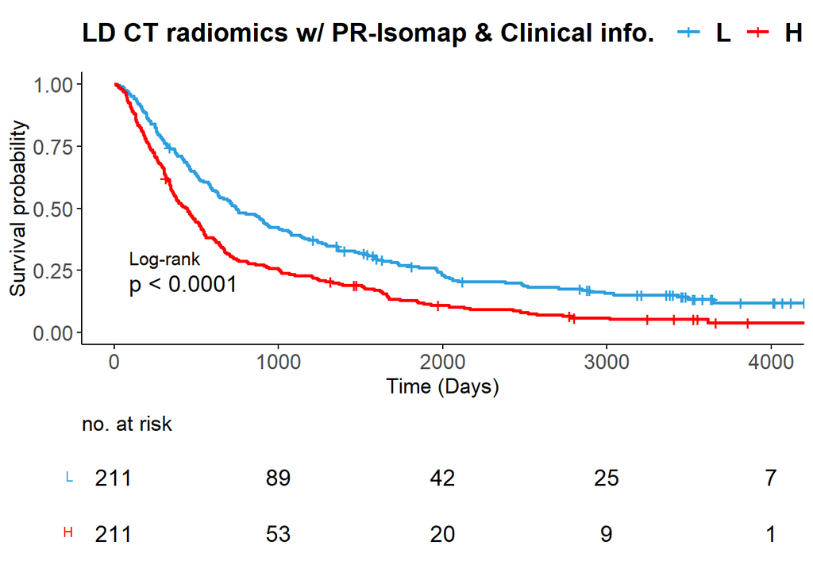

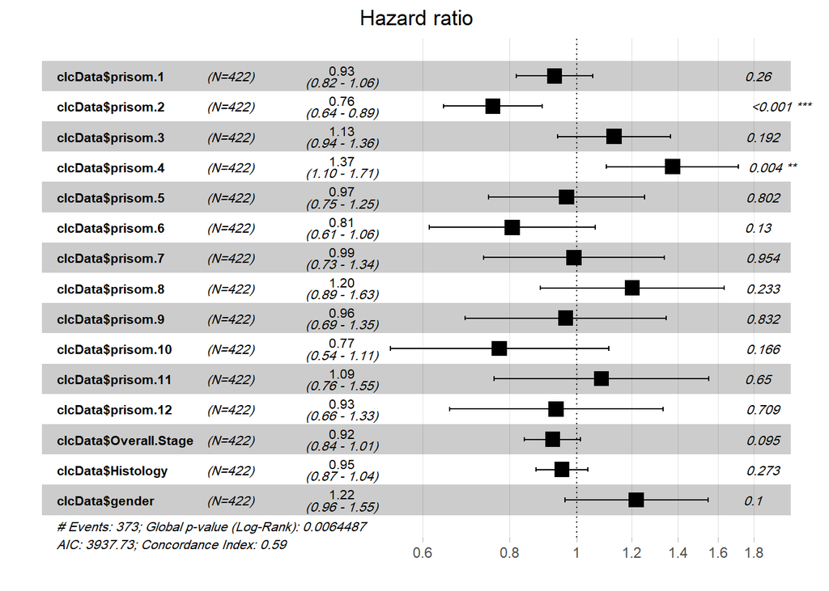